# cTP-net Vignette (Seurat v2)

Zilu Zhou

11/1/2019

Abstract

While single cell RNA sequencing (scRNA-seq) is invaluable for studying cell populations, cell-surface proteins are often integral markers of cellular function and serve as primary targets for therapeutic intervention. Here we propose a transfer learning framework, single *c*ell *T*ranscriptome to *P*rotein prediction with deep neural *net*work (cTP-net), to impute surface protein abundances from scRNA-seq data by learning from existing single-cell multi-omic resources. For more detail, please check our [biorixv preprint](https://www.biorxiv.org/content/10.1101/671180v1). See [list of surface proteins](https://github.com/zhouzilu/cTPnet/blob/master/SurfaceProteinList.md) we can predict for now.

# 1. Installation

## 1.1 Install cTP-net

### 1.1.1 Support Python package

First, install the supporting Python package ctpnetpy. See the source code of the package [here](http://github.com/zhouzilu/ctpnetpy)

```python
pip install cTPnet
```

If there is problem with PyTorch, refer to [pytorch website](https://pytorch.org/) for more details.

### 1.1.2 R package

Next, open R and install the R package cTPnet

```r
devtools::install_github("zhouzilu/cTPnet")
# If you do not want to update dependencies, please use the following command
devtools::install_github("zhouzilu/cTPnet",dependencies = FALSE)
```

### 1.1.3 Pretrained model

Download the pretrained model from [weights](https://github.com/zhouzilu/ctpnetpy/tree/developing/ctpnet/weight).

## 1.2 Install SAVER-X (Highly recommended)

In addition, if you want to denoise your raw scRNA counts, please follow the SAVER-X installation pipeline. Modified from https://github.com/jingshuw/SAVERX

### 1.2.1 Support Python package

Install supporting Python package sctransfer.

```python
pip install sctransfer
```

### 1.2.2 R package

Install R pacakge.

```r
devtools::install_github("jingshuw/SAVERX")
```

### 1.2.3 Pretrained model

Download the pretrained model from [weights](https://github.com/zhouzilu/ctpnetpy/tree/developing/ctpnet/weight).

Currently, SAVER-X do not support for super large data sets (test failed for 270,000 cells and 200GB RAM). cTP-net, on the other hand, can predict surface protein abundance relatively accurate without denoising.

# 2. Questions & issues

If you have any questions or problems when using cTPnet or ctpnetpy, please feel free to open a new issue [here](https://github.com/zhouzilu/cTPnet/issues). You can also email the maintainers of the corresponding packages –

- [Zilu Zhou](https://statistics.wharton.upenn.edu/profile/zhouzilu/) (zhouzilu at pennmedicine dot upenn dot edu)  
  Genomics and Computational Biology Graduate Group, UPenn
- [Nancy R. Zhang](https://statistics.wharton.upenn.edu/profile/nzh/) (nzh at wharton dot upenn dot edu)  
  Department of Statistics, UPenn

# 3. cTP-net analysis pipeline

To accurately impute surface protein abundance from scRNA-seq data, cTP-net employs two steps: (1) denoising of the scRNA-seq count matrix and (2) imputation based on the denoised data through a transcriptome-protein mapping (Figure 1). The initial denoising, by SAVERX, produces more accurate estimates of the RNA transcript relative abundances for each cell. Compared to the raw counts, the denoised relative expression values have significantly improved correlation with their cognate protein measurement.

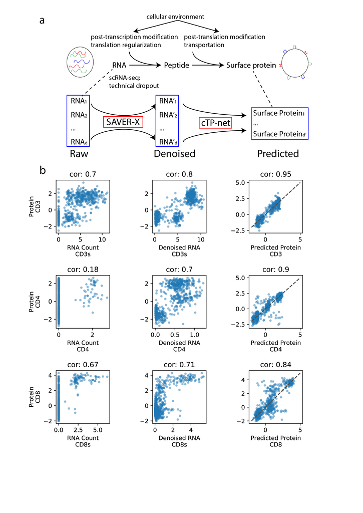

**Figure 1**. *(a)* Overview of cTP-net analysis pipeline, which learns a mapping from the denoised scRNA-seq data to the relative abundance of surface proteins, capturing multi-gene features that reflect the cellular environment and related processes. *(b)* For three example proteins, cross-cell scatter and correlation of CITE-seq measured abundances vs. (1) raw RNA count, (2) SAVER-X denoised RNA level, and (3) cTP-net predicted protein abundance.